# Practica 1 - Airbnb NYC 2025

### 3. Filtra los registros para mantener solo alojamientos con más de 10 reseñas yun precio menor a $500 por noche. Además, excluye valores faltantes para la columna host_location.

```r
df_filtrado_top_10 <- df %>%
  filter(
    number_of_reviews > 10,
    !is.na(host_location),
    price_num < 500
  )

options(scipen=999)
head(df_filtrado_top_10)
```

| id | listing_url | scrape_id | last_scraped | source | name | description | neighborhood_overview | picture_url | host_id | host_url | host_name | host_since | host_location | host_about | host_response_time | host_response_rate | host_acceptance_rate | host_is_superhost | host_thumbnail_url | host_picture_url | host_neighbourhood | host_listings_count | host_total_listings_count | host_verifications | host_has_profile_pic | host_identity_verified | neighbourhood | neighbourhood_cleansed | neighbourhood_group_cleansed | … |
| --- | --- | --- | --- | --- | --- | --- | --- | --- | --- | --- | --- | --- | --- | --- | --- | --- | --- | --- | --- | --- | --- | --- | --- | --- | --- | --- | --- | --- | --- | --- |
| 932642358896439680 | https://www.airbnb.com/rooms/932642358896439621 | 20250302010353 | 2025-03-02 | city scrape | Stylish top floor apt w/parking | The whole group will enjoy easy access to everything from this centrally located place. Sun filled top floor unit with spacious bedrooms-well equipped kitchen and modern bath. Convenient location near… | Pine Hills Neighborhood in Albany NY is full of both residents and businesses, located near the College of Saint Rose and UAlbany. The proximity to these universities makes Pine Hill a popular residen… | https://a0.muscache.com/pictures/prohost-api/Hosting-932642358896439621/original/2338f08d-c555-4ffb-a0da-23b8457420ac.jpeg | 232967878 | https://www.airbnb.com/users/show/232967878 | Diana | 2018-12-28 | Albany, NY | NA | within an hour | 99% | 97% | TRUE | https://a0.muscache.com/im/pictures/user/User-232967878/original/cea8ebfc-ac7a-4317-a182-2fe36680942c.jpeg?aki_policy=profile_small | https://a0.muscache.com/im/pictures/user/User-232967878/original/cea8ebfc-ac7a-4317-a182-2fe36680942c.jpeg?aki_policy=profile_x_medium | Delaware Avenue | 25 | 38 | ['phone'] | TRUE | TRUE | Neighborhood highlights | THIRTEENTH WARD | NA | … |
| 53567589 | https://www.airbnb.com/rooms/53567589 | 20250302010353 | 2025-03-02 | city scrape | Private Garden Apt in Downtown Albany\|Pets Allowed | Discover Lark Street - A Hip Albany Neighborhood. With countless restaurants, cafes, art galleries, special events, and more, this funky arts and entertainment district is a major Albany hotspot. The … | If you visit Albany’s Capital Region without seeing Lark Street, then you have indeed missed its unique and funky urban center. Lark Street is often referred to as the “Greenwich Village” of Albany’s … | https://a0.muscache.com/pictures/2e5b6926-a177-4bb6-b01f-9d085e3bbfdf.jpg | 433096110 | https://www.airbnb.com/users/show/433096110 | Brian | 2021-11-22 | Saratoga Springs, NY | NA | within an hour | 100% | 94% | TRUE | https://a0.muscache.com/im/pictures/user/30c0b064-316a-436f-8b55-6ed68fc044fd.jpg?aki_policy=profile_small | https://a0.muscache.com/im/pictures/user/30c0b064-316a-436f-8b55-6ed68fc044fd.jpg?aki_policy=profile_x_medium | New Scotland | 4 | 6 | ['email', 'phone'] | TRUE | TRUE | Neighborhood highlights | SIXTH WARD | NA | … |
| 20671966 | https://www.airbnb.com/rooms/20671966 | 20250302010353 | 2025-03-02 | city scrape | The Metropolitan | This full apartment is located on the 3rd floor in this beautiful Victorian. All the comforts of home. Nothing shared,has a full bathtub,full kitchen,one bedroom with a queen bed. Living room and an o… | NA | https://a0.muscache.com/pictures/hosting/Hosting-U3RheVN1cHBseUxpc3Rpbmc6MjA2NzE5NjY%3D/original/c836c55d-e702-4e25-8177-166eee63cd1b.jpeg | 98744672 | https://www.airbnb.com/users/show/98744672 | Bela | 2016-10-08 | Albany, NY | My name is Bela Schuch, I am manager of The Inn at South Lake here in Albany , we hope you enjoy your stay with us at the Inn Thank you ! | within an hour | 100% | 98% | TRUE | https://a0.muscache.com/im/pictures/user/eccd4f9b-870c-4c2b-ae97-3fb7f5feb710.jpg?aki_policy=profile_small | https://a0.muscache.com/im/pictures/user/eccd4f9b-870c-4c2b-ae97-3fb7f5feb710.jpg?aki_policy=profile_x_medium | Pine Hills | 8 | 8 | ['email', 'phone', 'work_email'] | TRUE | TRUE | NA | NINTH WARD | NA | … |
| 24606880 | https://www.airbnb.com/rooms/24606880 | 20250302010353 | 2025-03-02 | city scrape | The Western Suite | Located in a huge Victorian, this beautiful suite comes furnished with a queen size bed, desk, dresser, TV, Wifi, small fridge and Private bath.We supply the towels, linens and starter toiletries. | NA | https://a0.muscache.com/pictures/e8183a7b-a392-4be6-b7c0-22a974472edb.jpg | 98744672 | https://www.airbnb.com/users/show/98744672 | Bela | 2016-10-08 | Albany, NY | My name is Bela Schuch, I am manager of The Inn at South Lake here in Albany , we hope you enjoy your stay with us at the Inn Thank you ! | within an hour | 100% | 98% | TRUE | https://a0.muscache.com/im/pictures/user/eccd4f9b-870c-4c2b-ae97-3fb7f5feb710.jpg?aki_policy=profile_small | https://a0.muscache.com/im/pictures/user/eccd4f9b-870c-4c2b-ae97-3fb7f5feb710.jpg?aki_policy=profile_x_medium | Pine Hills | 8 | 8 | ['email', 'phone', 'work_email'] | TRUE | TRUE | NA | NINTH WARD | NA | … |
| 1097995825442731776 | https://www.airbnb.com/rooms/1097995825442731795 | 20250302010353 | 2025-03-02 | city scrape | New Center square studio | Kick back and relax in this calm, stylish space. Garden level studio just recently updated. Open floor plan offering everything you need to come home after a long day. Great location minutes off of La… | NA | https://a0.muscache.com/pictures/hosting/Hosting-1097995825442731795/original/24323334-bcee-4d0e-9931-f76092df7b63.jpeg | 232967878 | https://www.airbnb.com/users/show/232967878 | Diana | 2018-12-28 | Albany, NY | NA | within an hour | 99% | 97% | TRUE | https://a0.muscache.com/im/pictures/user/User-232967878/original/cea8ebfc-ac7a-4317-a182-2fe36680942c.jpeg?aki_policy=profile_small | https://a0.muscache.com/im/pictures/user/User-232967878/original/cea8ebfc-ac7a-4317-a182-2fe36680942c.jpeg?aki_policy=profile_x_medium | Delaware Avenue | 25 | 38 | ['phone'] | TRUE | TRUE | NA | SIXTH WARD | NA | … |
| 53483727 | https://www.airbnb.com/rooms/53483727 | 20250302010353 | 2025-03-02 | city scrape | Spacious Urban APT w/4BR & Office in Albany | Visiting Albany for work, vacation, or to visit family? The Twitchell Estate is a spacious 4BR home that will be perfect for your stay. This elegantly designed Boho Chic rental comes with amenities su… | The New Scotland neighborhood is one of the best places to stay in New York. This area offers residents and guests an urban suburban mix feel. There are many young professionals that live in this area… | https://a0.muscache.com/pictures/miso/Hosting-53483727/original/640fe42e-feb6-4a37-bab7-f4ab9d853085.jpeg | 433096110 | https://www.airbnb.com/users/show/433096110 | Brian | 2021-11-22 | Saratoga Springs, NY | NA | within an hour | 100% | 94% | TRUE | https://a0.muscache.com/im/pictures/user/30c0b064-316a-436f-8b55-6ed68fc044fd.jpg?aki_policy=profile_small | https://a0.muscache.com/im/pictures/user/30c0b064-316a-436f-8b55-6ed68fc044fd.jpg?aki_policy=profile_x_medium | New Scotland | 4 | 6 | ['email', 'phone'] | TRUE | TRUE | Neighborhood highlights | FOURTEENTH WARD | NA | … |

### 4.Ordena los datos de mayor a menor disponibilidad (availability_365).

```r
df_ordenado_availability <- df_filtrado_top_10 %>%
  arrange(desc(availability_365))

options(scipen=999)
head(df_ordenado_availability)
```

| id | listing_url | scrape_id | last_scraped | source | name | description | neighborhood_overview | picture_url | host_id | host_url | host_name | host_since | host_location | host_about | host_response_time | host_response_rate | host_acceptance_rate | host_is_superhost | host_thumbnail_url | host_picture_url | host_neighbourhood | host_listings_count | host_total_listings_count | host_verifications | host_has_profile_pic | host_identity_verified | neighbourhood | neighbourhood_cleansed | neighbourhood_group_cleansed | … |
| --- | --- | --- | --- | --- | --- | --- | --- | --- | --- | --- | --- | --- | --- | --- | --- | --- | --- | --- | --- | --- | --- | --- | --- | --- | --- | --- | --- | --- | --- | --- |
| 11639446 | https://www.airbnb.com/rooms/11639446 | 20250302010353 | 2025-03-02 | city scrape | $55twin($30 foreign student)FreeBF Noa/c no smoke | Regular breakfast freeLunch packed $5Dinner Plate $10We updated cleaning protocol because of COVID-19 pandemicOUR PRIORITY IS ORGANIC LIFE SO OTHER THING IS LESS IMPORTANT FREE LAUNDRY AIR CONDITIONIN… | One block away to unique organic honest weigh Co OpOne block away to shop riteOne block away to Central AvenueStreet parking | https://a0.muscache.com/pictures/1129f67c-dfb2-4a2c-bb1d-914a3245d600.jpg | 61700428 | https://www.airbnb.com/users/show/61700428 | Adam | 2016-03-05 | Albany, NY | Guest's satisfaction and happiness is much more important than money!\r\n顾客的满意远比赚钱重要!我的初衷是帮助更多的人､服务更多的人~\nWe provide emotional comfort more than physically comfortable\n我们提供的情感舒适度超过身体舒适度. | N/A | N/A | 63% | FALSE | https://a0.muscache.com/im/pictures/user/fcc2b09f-611c-457c-828b-43336a05dfae.jpg?aki_policy=profile_small | https://a0.muscache.com/im/pictures/user/fcc2b09f-611c-457c-828b-43336a05dfae.jpg?aki_policy=profile_x_medium | NA | 2 | 2 | ['email', 'phone'] | TRUE | TRUE | Neighborhood highlights | ELEVENTH WARD | NA | … |
| 47828453 | https://www.airbnb.com/rooms/47828453 | 20250302010353 | 2025-03-02 | city scrape | Holidays in Center Square Albany 2BR Apt w/Parking | NO SMOKINGDiscover peace of mind in our professionally sanitized 2-bdrm apt. in Center Square Albany. Perfectly designed for extended stays, this apartment features 24/7 security cameras and a hardwir… | NA | https://a0.muscache.com/pictures/47b30ae3-42bc-4164-aa1e-1d49344ebf3b.jpg | 299638115 | https://www.airbnb.com/users/show/299638115 | Flerida | 2019-10-03 | Albany, NY | Hi! My name is Dom . Due to my lineage in real estate and hospitality with my mom Flerida, I have developed a passion for hospitality and real estate, always looking to create amazing guest experience… | within an hour | 100% | 100% | FALSE | https://a0.muscache.com/im/pictures/user/89182882-befc-488f-9851-e7b80ad0c3a4.jpg?aki_policy=profile_small | https://a0.muscache.com/im/pictures/user/89182882-befc-488f-9851-e7b80ad0c3a4.jpg?aki_policy=profile_x_medium | NA | 3 | 4 | ['email', 'phone', 'work_email'] | TRUE | TRUE | NA | THIRD WARD | NA | … |
| 1189249179392132608 | https://www.airbnb.com/rooms/1189249179392132534 | 20250302010353 | 2025-03-02 | city scrape | Lovely 1 Bedroom with Parking | Welcome to our newly renovated one-bedroom apartment located on the second floor, just minutes away from Albany Med and Saint Peters, walking distance from neighborhood park. Easy access to state offi… | NA | https://a0.muscache.com/pictures/prohost-api/Hosting-1189249179392132534/original/c8128533-5557-4a52-960e-58c3d7118f8f.jpeg | 37769478 | https://www.airbnb.com/users/show/37769478 | Erion | 2015-07-07 | Albany, NY | Hello just a traveler who loves to enjoy others living space and learn about their culture as I share my space and culture with others. | within an hour | 100% | 99% | NA | https://a0.muscache.com/im/pictures/user/19024941-bf47-4590-ad50-81973610b5b5.jpg?aki_policy=profile_small | https://a0.muscache.com/im/pictures/user/19024941-bf47-4590-ad50-81973610b5b5.jpg?aki_policy=profile_x_medium | Pine Hills | 15 | 15 | ['email', 'phone'] | TRUE | TRUE | NA | TENTH WARD | NA | … |
| 28341274 | https://www.airbnb.com/rooms/28341274 | 20250302010353 | 2025-03-02 | city scrape | Private room in historic building on the park | My home is within walking distance of the Capital, the Empire State Plaza, Albany Medical Center, and many restaurants and museums. It's directly across from beautiful Washington Park, and it's an ide… | Center Square is a great area, Lark Street is loaded with shops and coffee houses and restaurants. Absolutely everything you need is within walking distance. Washington Park is the"crown jewel" of Alb… | https://a0.muscache.com/pictures/0edd211e-34ea-4884-8b70-78ebe5db5440.jpg | 54394342 | https://www.airbnb.com/users/show/54394342 | Alice | 2016-01-12 | Albany, NY | If you're looking for a clean quiet place that feels like home then you're going to love it here! If I'm cooking I'd welcome you to join me, or direct you to a dining experience in Albany. I love peop… | within an hour | 100% | 89% | TRUE | https://a0.muscache.com/im/pictures/user/User-54394342/original/1e3bbac3-f041-4076-ab8c-e2fb042e2631.jpeg?aki_policy=profile_small | https://a0.muscache.com/im/pictures/user/User-54394342/original/1e3bbac3-f041-4076-ab8c-e2fb042e2631.jpeg?aki_policy=profile_x_medium | NA | 1 | 5 | ['email', 'phone'] | TRUE | TRUE | Neighborhood highlights | SIXTH WARD | NA | … |
| 12799126 | https://www.airbnb.com/rooms/12799126 | 20250302010353 | 2025-03-02 | city scrape | Private Room in the Hearth of the Albany | Perfect location with clean comfortable private room surrounded by bars restaurants, market, parks and many more. | It's perfect location for any kind of events, there are bars around house,restaurants, market right next to us, bus stop and moreover | https://a0.muscache.com/pictures/3e656127-d8e2-4743-a405-1b91d81c4dc7.jpg | 69729286 | https://www.airbnb.com/users/show/69729286 | Musab | 2016-05-01 | Albany, NY | NA | within a few hours | 100% | 73% | FALSE | https://a0.muscache.com/im/pictures/user/5507d01f-fe58-4066-9900-5de519b5dfd6.jpg?aki_policy=profile_small | https://a0.muscache.com/im/pictures/user/5507d01f-fe58-4066-9900-5de519b5dfd6.jpg?aki_policy=profile_x_medium | Capitol Hill | 2 | 2 | ['email', 'phone'] | TRUE | TRUE | Neighborhood highlights | SIXTH WARD | NA | … |
| 816085193659797888 | https://www.airbnb.com/rooms/816085193659797849 | 20250302010353 | 2025-03-02 | city scrape | Cozy Apartment across the Park | Perfect location with exposed brick 1 bedroom apartment located in the heart of Albany across Washington park minutes from Albany Med or state offices. Close to many restaurants and bars. | NA | https://a0.muscache.com/pictures/miso/Hosting-816085193659797849/original/27fdee41-2e4b-43b5-a90e-d4c5fc7265ff.jpeg | 37769478 | https://www.airbnb.com/users/show/37769478 | Erion | 2015-07-07 | Albany, NY | Hello just a traveler who loves to enjoy others living space and learn about their culture as I share my space and culture with others. | within an hour | 100% | 99% | NA | https://a0.muscache.com/im/pictures/user/19024941-bf47-4590-ad50-81973610b5b5.jpg?aki_policy=profile_small | https://a0.muscache.com/im/pictures/user/19024941-bf47-4590-ad50-81973610b5b5.jpg?aki_policy=profile_x_medium | Pine Hills | 15 | 15 | ['email', 'phone'] | TRUE | TRUE | NA | SIXTH WARD | NA | … |

### 5. Crea una nueva columna llamada total_revenue, que represente el ingreso potencial en un año (price * availability_365).

```r
df_nueva_columna <- df_ordenado_availability %>%
  mutate(total_revenue = price_num * availability_365)

options(scipen=999)
head(select(df_nueva_columna, price_num, availability_365, total_revenue))
```

| price_num | availability_365 | total_revenue |
| --- | --- | --- |
| 55 | 365 | 20075 |
| 115 | 365 | 41975 |
| 80 | 364 | 29120 |
| 75 | 364 | 27300 |
| 47 | 364 | 17108 |
| 84 | 364 | 30576 |

### 6.Selecciona las columnas host_location, room_type, price, availability_365, total_revenue y number_of_reviews.

```r
df_final <- df_nueva_columna %>%
  select(
    host_location, room_type,
    price = price_num,
    availability_365, total_revenue,
    number_of_reviews
  )

options(scipen=999)
head(df_final)
```

| host_location | room_type | price | availability_365 | total_revenue | number_of_reviews |
| --- | --- | --- | --- | --- | --- |
| Albany, NY | Private room | 55 | 365 | 20075 | 231 |
| Albany, NY | Entire home/apt | 115 | 365 | 41975 | 20 |
| Albany, NY | Entire home/apt | 80 | 364 | 29120 | 23 |
| Albany, NY | Private room | 75 | 364 | 27300 | 90 |
| Albany, NY | Private room | 47 | 364 | 17108 | 28 |
| Albany, NY | Entire home/apt | 84 | 364 | 30576 | 33 |

## Parte II. Resúmenes y agrupaciones

### 1. Agrupa los datos por host_location y calcula:

- Precio promedio por noche.
- Número total de alojamientos.
- Ingreso potencial promedio (mean(total_revenue)).

```r
resumen_host_loc <- df_final %>%
  group_by(host_location) %>%
  summarize(
    avg_price = mean(price, na.rm = TRUE),
    total_listings = n(),
    avg_total_revenue = mean(total_revenue, na.rm = TRUE),
  ) %>%
  arrange(desc(total_listings))

options(scipen=999)
head(resumen_host_loc)
```

| host_location | avg_price | total_listings | avg_total_revenue |
| --- | --- | --- | --- |
| Albany, NY | 103.56329 | 158 | 23687.53 |
| New York, NY | 88.87500 | 8 | 12698.62 |
| Colonie, NY | 77.25000 | 4 | 5923.50 |
| Latham, NY | 63.50000 | 4 | 21830.00 |
| Gloversville, NY | 34.33333 | 3 | 10580.33 |
| Saratoga Springs, NY | 119.00000 | 3 | 31649.00 |

### Agrupa los datos por room_type dentro de cada host_location y calcular:

- Disponibilidad promedio.

```r
resumen_room_type <- df_final %>%
  group_by(host_location, room_type) %>%
  summarise(
    avg_availability = mean(availability_365, na.rm = TRUE),
    n = n(),
  ) %>%
  arrange(host_location, desc(avg_availability))

head(resumen_room_type)
```

| host_location | room_type | avg_availability | n |
| --- | --- | --- | --- |
| Albany, NY | Entire home/apt | 236.9469 | 113 |
| Albany, NY | Private room | 219.8444 | 45 |
| Colonie, NY | Entire home/apt | 76.0000 | 4 |
| Delmar, NY | Entire home/apt | 171.0000 | 1 |
| Fort Walton Beach, FL | Entire home/apt | 218.0000 | 1 |
| Gloversville, NY | Private room | 305.0000 | 3 |

## Parte III. Visualización de datos con `ggplot2`

### 1. Gráfico 1. Dispersión (scatter plot)

- Crea un gráfico de dispersión donde el eje X sea el precio y el eje Y el número de reseñas (number_of_reviews).
- Diferencia los puntos por room_type, utiliza el parámetro color en la función aes.

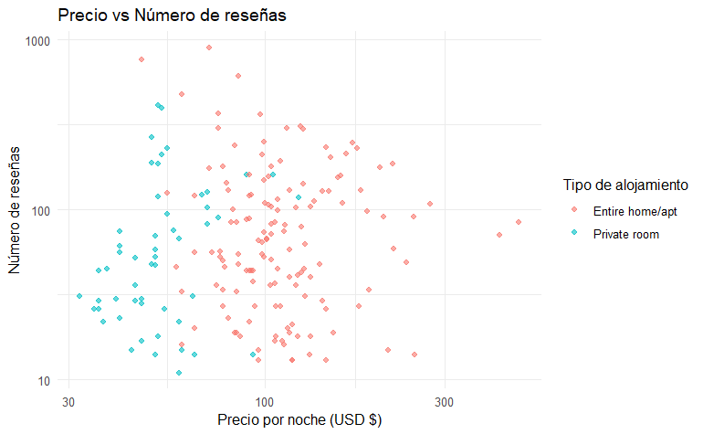

```r
library(ggplot2)

ggplot(df_final, aes(x = price, y = number_of_reviews, color = room_type)) +
  geom_point(alpha = 0.6) +
  labs(
    title = "Precio vs Número de reseñas",
    x = "Precio por noche (USD $)",
    y = "Número de reseñas",
    color = "Tipo de alojamiento"
  ) +
  theme_minimal()+
  scale_x_log10() +
  scale_y_log10()
```

```r
NA
```

### 2. Gráfico de barras (bar plot)

- Crea un gráfico con la evolución del precio promedio de los alojamientos en función del room_type.
- Usa geom_col(), asegurándose de que se diferencie el tipo de alojamiento con el parámetro fill en la función aes.

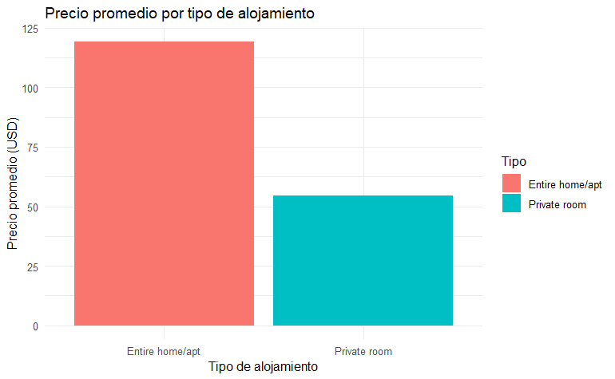

```r
precio_por_tipo <- df_final %>%
  group_by(room_type) %>%
  summarize(
    avg_price = mean(price, na.rm = TRUE),
    .groups = "drop"
  )

ggplot(precio_por_tipo, aes(x = room_type, y = avg_price, fill = room_type)) +
  geom_col() +
  labs(
    title = "Precio promedio por tipo de alojamiento",
    x = "Tipo de alojamiento",
    y = "Precio promedio (USD)",
    fill = "Tipo"
  ) +
  theme_minimal()
```

#### Hallazgos – Gráfico 2

- Se observa que los alojamientos completos presentan un precio promedio más alto, superior a los 100 USD por noche.
- Los Private room tienen un precio promedio significativamente menor, en torno a los 50–60 USD por noche.
- Esta diferencia muestra que el tipo de alojamiento es un factor determinante en el precio: alquilar un espacio completo implica un costo mayor que una habitación privada.

### 3. Gráfico facetado (facet_wrap)

- Crea un gráfico de dispersión donde se muestre la relación entre disponibilidad (availability_365) y precio (price).
- Divide el gráfico en paneles por host_location usando facet_wrap(~host_location).

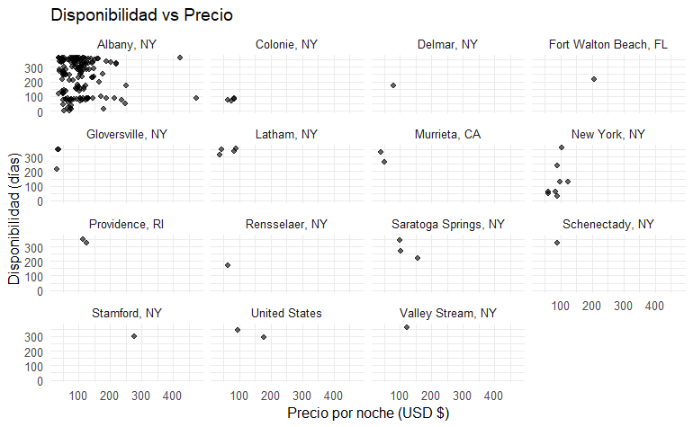

```r
ggplot(df_final, aes(x = price, y = availability_365)) +
  geom_point(alpha = 0.6) +
  facet_wrap(~ host_location)  + #~host_location
  labs(
    title = "Disponibilidad vs Precio",
    x = "Precio por noche (USD $)",
    y = "Disponibilidad (días)"
  ) +
  theme_minimal()
```